# exercise-05

Sam Smith

2/23/2022

Challenge 1

```r
library(tidyverse)
library(dplyr)
f <- "https://raw.githubusercontent.com/difiore/ada-2022-datasets/main/IMDB-movies.csv"
d <- read_csv(f, col_names = TRUE)
```

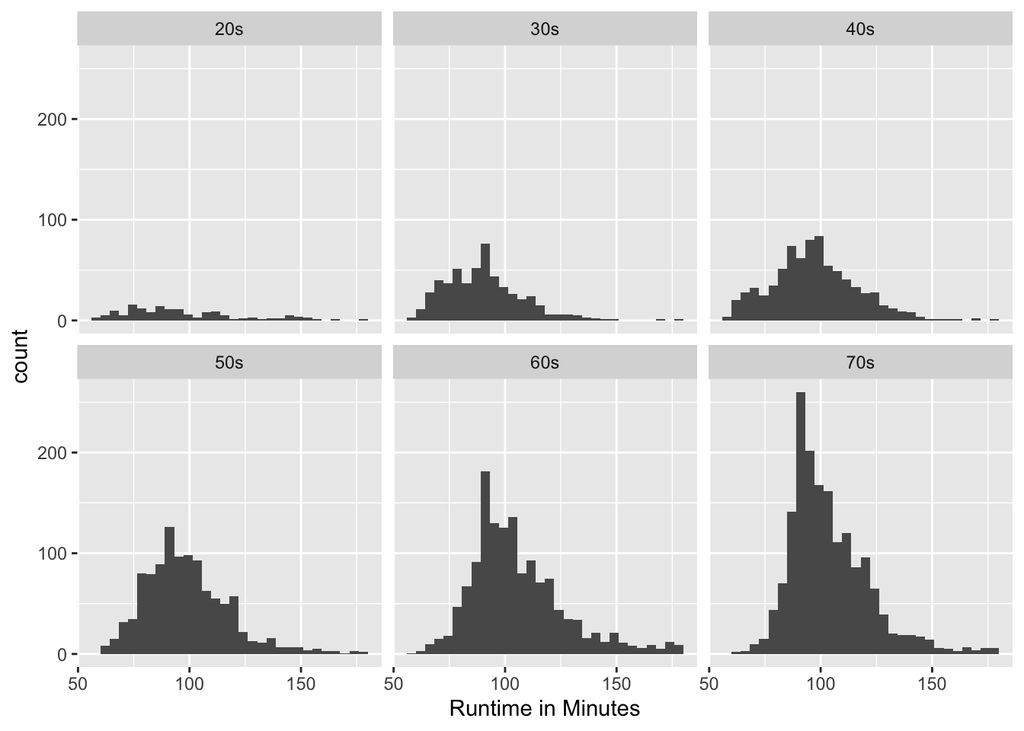

```r
new_df <- d %>% filter(startYear %in% 1920:1979 & runtimeMinutes >=60 & runtimeMinutes <= 180) %>% mutate("decade" = case_when(startYear <= 1929 ~ "20s",
                                startYear <=1939 ~ "30s",
                                startYear <=1949 ~ "40s",
                                startYear <=1959 ~ "50s",
                                startYear <=1969 ~ "60s",
                                startYear <=1979 ~ "70s"))

# plot histogram with ggplot
ggplot(new_df,aes(x=runtimeMinutes)) +
  xlab("Runtime in Minutes") +
  geom_histogram(na.rm=TRUE) +
  facet_wrap(~decade,ncol=3)
```

Challenge 1 continued … Use a 1 line statement to calculate the population mean and standard deviation in runtimeMinutes for each decade and save the results in a new dataframe, results NOTE TO SELF FIX THIS

```r
popSD <- function(x){sqrt(sum((x-mean(x))^2)/(length(x)))}
results <- summarise(group_by(new_df,decade),
                     n_cases = n(),
                     popMean = mean(runtimeMinutes,na.rm=TRUE),
                     popSD = popSD(runtimeMinutes))
```

Challenge 1 continued… standard error = sd / square root of sample size

```r
# calculate mean and sd of single sample of 100 per decade
single_sample <- new_df %>% group_by(decade) %>% sample_n(size=100,replace=FALSE) %>%
  summarize(sample_mean = mean(runtimeMinutes,na.rm=TRUE),
            sample_sd = sd(runtimeMinutes,na.rm=TRUE))
# calculate standard error for estimate of pop mean
stderror_singlesample <- single_sample$sample_sd / sqrt(100)

# actual pop mean and sd for dataset
results
```

```
## # A tibble: 6 × 4
##   decade n_cases popMean popSD
##   <chr>    <int>   <dbl> <dbl>
## 1 20s        152    96.3  26.1
## 2 30s        530    90.3  17.3
## 3 40s        782    97.2  19.1
## 4 50s       1081    98.9  19.2
## 5 60s       1386   106.   21.2
## 6 70s       1720   104.   18.0
```

```r
stderror_population <- results$popSD / sqrt(results$n_cases)
```

Standard error for the single sample of 100 samples per decade is higher than in the population, but how much higher varies based on the actual number of entries for each decade. We have a larger difference between sample standard error and population standard error for decades with lots of movie entries.

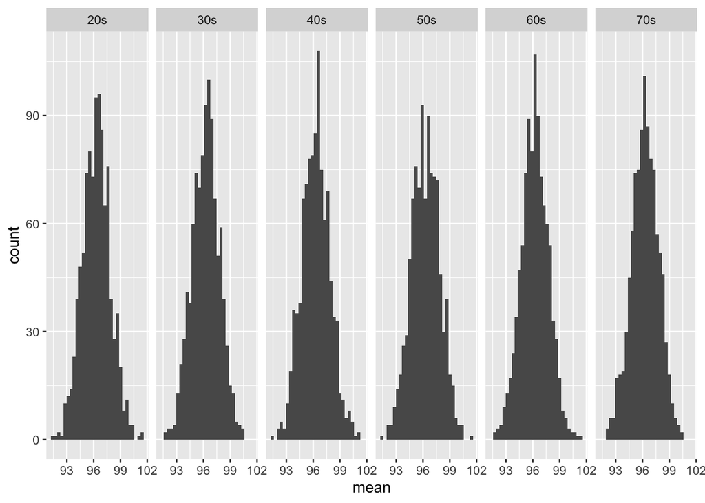

```r
# generate sampling distribution of mean runtimemins for each decade by drawing
# 1000 samples of 100 movies from each decade
library(infer)
reps <- 1000
n <- 100
decade <- c("20s","30s","40s","50s","60s","70s")
samp_distr_bydec <- tibble("replicate"=numeric(),
                           "mean"=numeric(),
                           "sd"=numeric(),
                           "decade"=character())
for(i in 1:length(decade)){
  df <- filter(new_df,decade == decade[i]) %>%
    rep_sample_n(size=n,reps=reps,replace=FALSE) %>%
    group_by(replicate) %>%
    summarize(mean=mean(runtimeMinutes,na.rm=TRUE),
              sd=sd(runtimeMinutes,na.rm=TRUE)) %>%
    mutate("decade"=rep(decade[i],1000))
  samp_distr_bydec <- bind_rows(samp_distr_bydec,df)
}

# calculate mean and sd of sampling distribution of sample means for each decade
summary_sampdistr <- samp_distr_bydec %>%
  group_by(decade) %>%
  summarize(mean=mean(mean),
            sd=sd(sd))
# plot sampling distribution for each decade
# mean
ggplot(data=samp_distr_bydec, aes(x=mean)) +
  geom_histogram() + facet_grid(~decade)
```

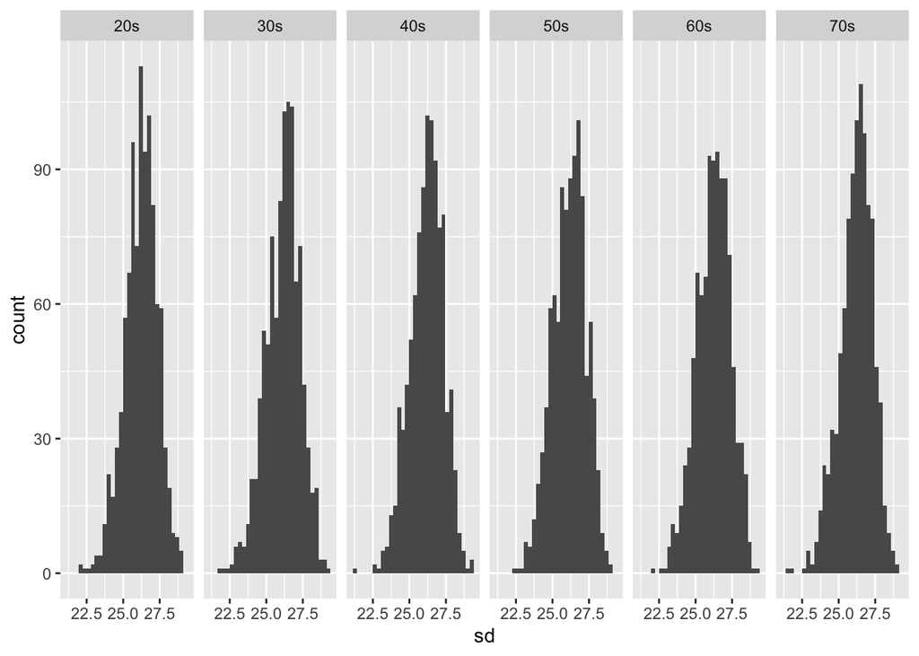

```r
ggplot(data=samp_distr_bydec, aes(x=sd)) +
  geom_histogram() + facet_grid(~decade)
```

These plots are shaped like an normal curve.

Last part of challenge 1: compare the SE in runtimeMinutes for samples (size = 100) from each decade as estimated from your first sample of 100 movies (1), from the known population SD for each decade (2), and from sampling distribution of sample means for each decade (3) NTS: standard error = sd / square root of sample size

```r
# SE in runtime minutes as estimated from first sample of 100 movies - calculated above
stderror_singlesample
```

```
## [1] 2.383545 1.650956 1.739974 2.131197 2.283020 1.623988
```

```r
# SE in runtime minutes as etimated from known pop SD for each decade - calculated above
stderror_population
```

```
## [1] 2.1182064 0.7502683 0.6834254 0.5838933 0.5701026 0.4329122
```

```r
# SE in runtime minutes as estimated from sampling distribution of sample means for each decade
(stderror_sampdistr <- summary_sampdistr$sd / sqrt(1000))
```

```
## [1] 0.03518344 0.03712289 0.03625112 0.03629904 0.03656665 0.03555079
```

standard error is really tiny calculated from the sampling distribution. Standard error for single sample and population are similar where the sample sizes were about equal but much smaller in the population data when sample sizes were much larger in the complete dataset.

Challenge 2:

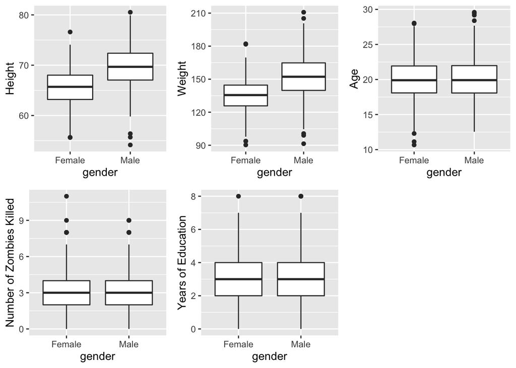

```r
library(tidyverse)
library(dplyr)
library(ggplot2)
library(cowplot)
f <- "https://raw.githubusercontent.com/difiore/ada-2022-datasets/main/zombies.csv"
z <- read_csv(f, col_names = TRUE)
# make function to calculate the population standard deviation
popSD <- function(x){sqrt(sum((x-mean(x))^2)/(length(x)))}
pop_mean_sd <- z %>% summarize(mean_height = mean(height,na.rm=TRUE),
                               sd_height = popSD(height),
                               mean_weight = mean(weight,na.rm=TRUE),
                               sd_weight = popSD(weight),
                               mean_age = mean(age,na.rm=TRUE),
                               sd_age = popSD(age),
                               mean_zombieskilled = mean(zombies_killed,na.rm=TRUE),
                               sd_zombieskilled = popSD(zombies_killed),
                               mean_years_ed = mean(years_of_education,na.rm=TRUE),
                               sd_years_ed = popSD(years_of_education))
# plot each variable by gender
p1 <- ggplot(z,aes(x=gender,y=height)) + geom_boxplot(na.rm=TRUE) + ylab("Height")
p2 <- ggplot(z,aes(x=gender,y=weight)) + geom_boxplot(na.rm=TRUE) + ylab("Weight")
p3 <- ggplot(z,aes(x=gender,y=age)) + geom_boxplot(na.rm=TRUE) + ylab("Age")
p4 <- ggplot(z,aes(x=gender,y=zombies_killed)) + geom_boxplot(na.rm=TRUE) + ylab("Number of Zombies Killed")
p5 <- ggplot(z,aes(x=gender,y=years_of_education)) + geom_boxplot(na.rm=TRUE) + ylab("Years of Education")
plot_grid(
  p1,
  p2,
  p3,
  p4,
  p5
)
```

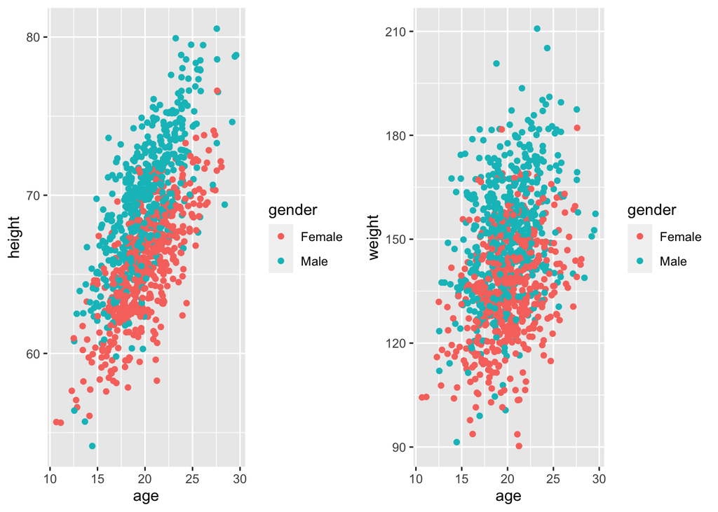

```r
# scatterplots of height and weight in relation to age (x var) with different colored points for gender
pl1 <- ggplot(z,aes(x=age,y=height,color=gender)) + geom_point()
pl2 <- ggplot(z,aes(x=age,y=weight,color=gender)) +geom_point()
plot_grid(
  pl1,
  pl2
)
```

Age and height are strongly positively correlated in both men and women (as expected). Women in general are shorter than men at all ages. Age and weight is also positively correlated but it seems to be not as strong as the correlation between age and height. Again, men in general weigh more than women at all ages.

Do each of the quantitative variables seem drawn from a normal distribution? If not, what do they seem drawn from?

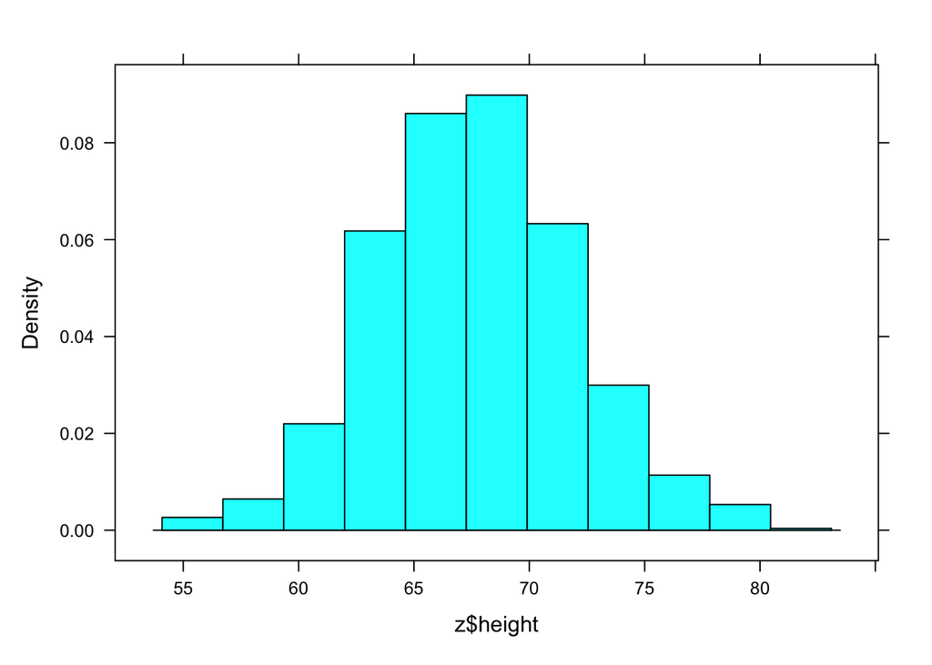

```r
library(mosaic)
# quantitative variables = height, weight, zombies_killed, years_of_education
histogram(z$height)
```

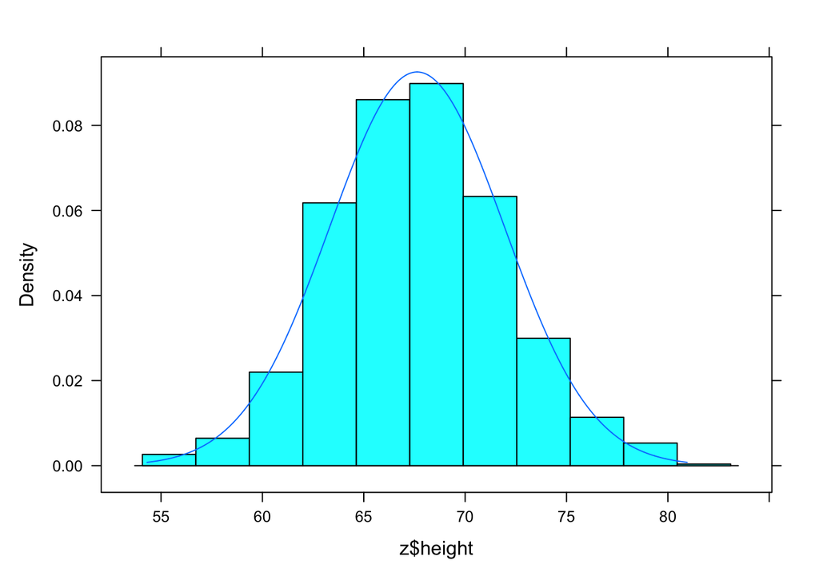

```r
plotDist("norm",mean = mean(z$height),sd = sd(z$height),add=TRUE) # yes height seems normally distributed
```

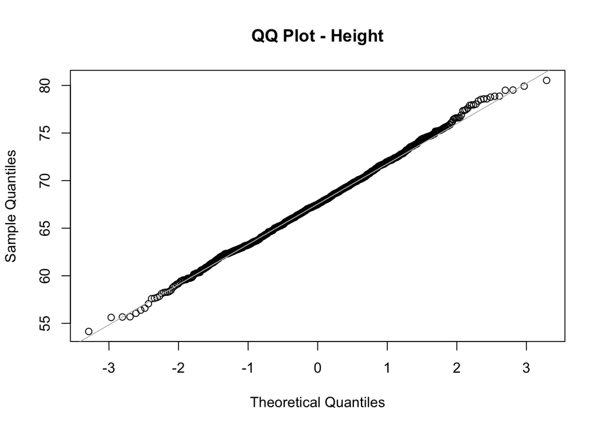

```r
qqnorm(z$height, main = "QQ Plot - Height")
qqline(z$height, col = "gray")
```

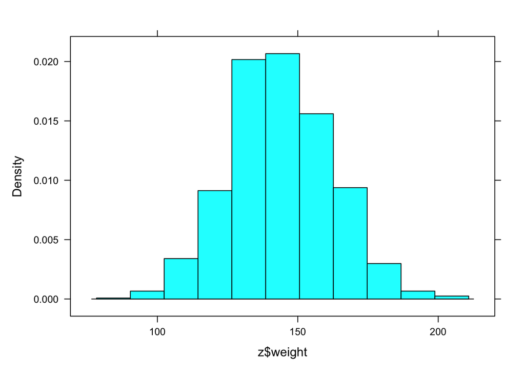

```r
histogram(z$weight)
```

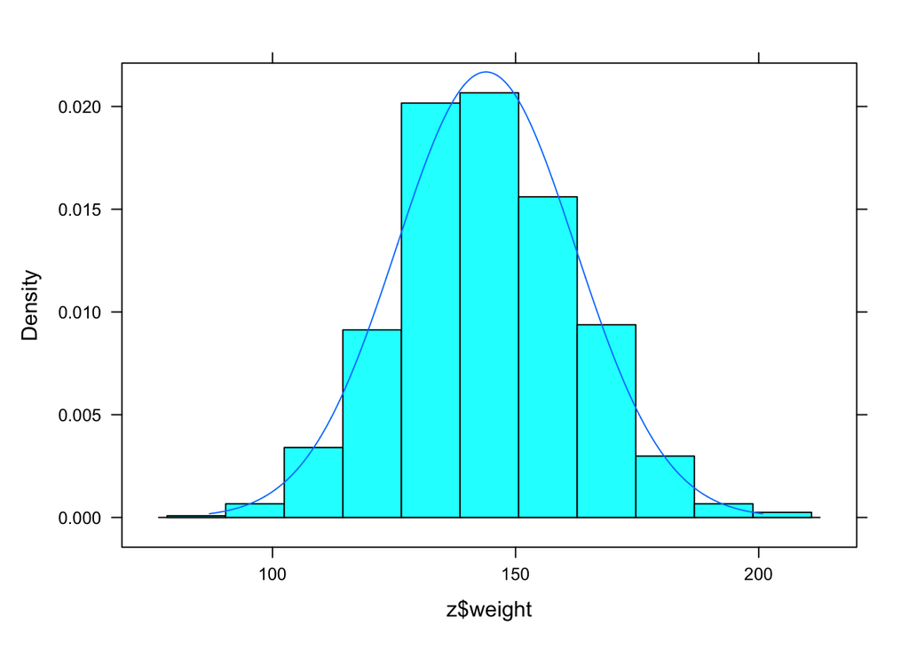

```r
plotDist("norm",mean = mean(z$weight),sd = sd(z$weight),add=TRUE) # yes weight seems normally distributed
```

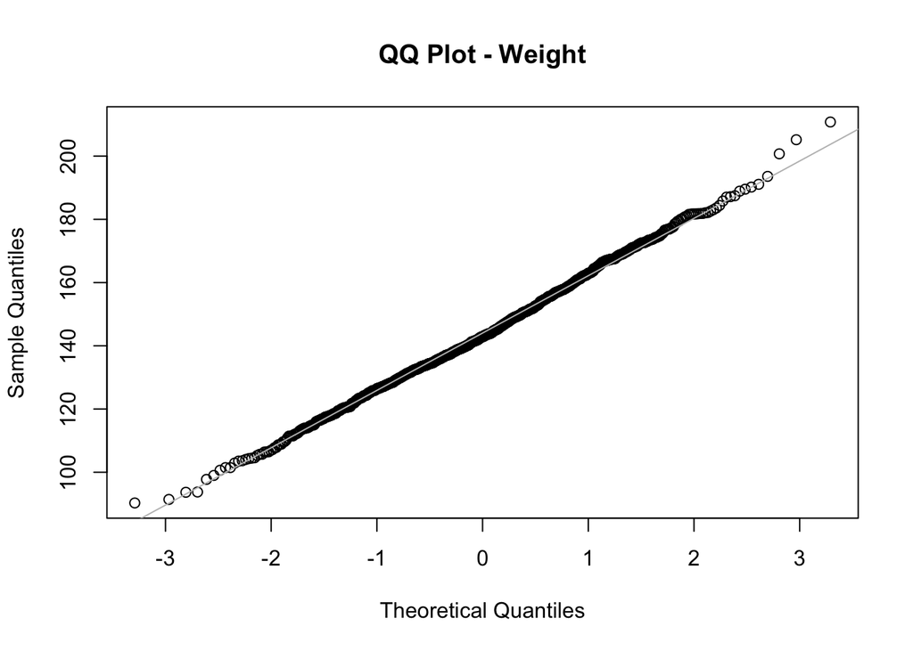

```r
qqnorm(z$weight, main = "QQ Plot - Weight")
qqline(z$weight, col = "gray")
```

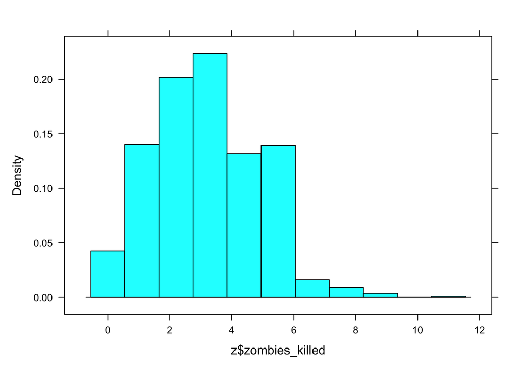

```r
histogram(z$zombies_killed)
```

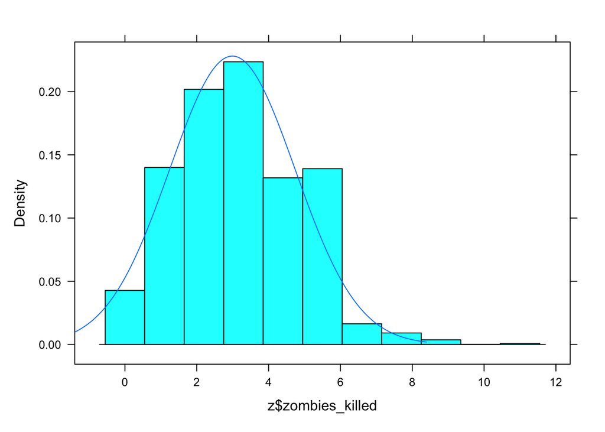

```r
plotDist("norm",mean = mean(z$zombies_killed),sd = sd(z$zombies_killed),add=TRUE)
```

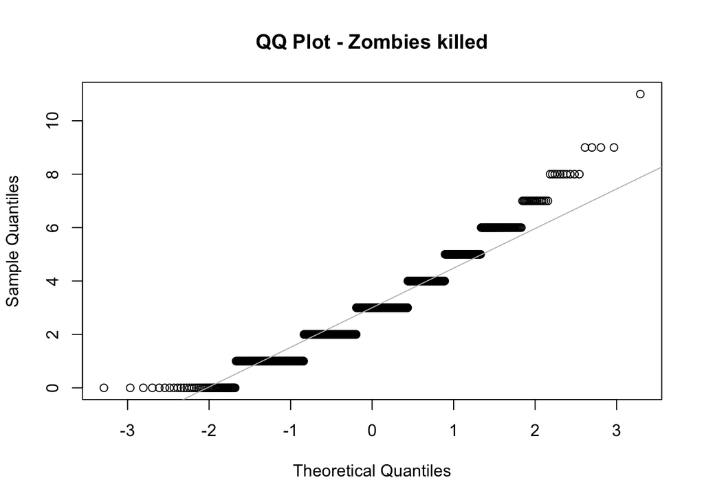

```r
qqnorm(z$zombies_killed, main = "QQ Plot - Zombies killed")
qqline(z$zombies_killed, col = "gray") # not looking normal
```

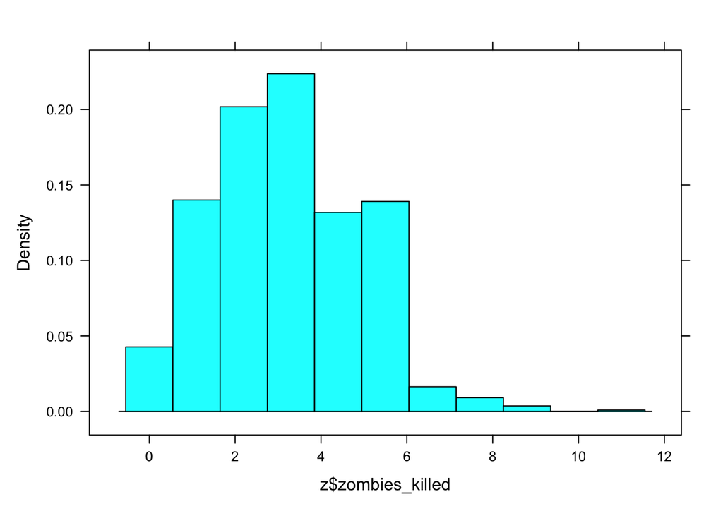

```r
# let's try a poisson distribution
histogram(z$zombies_killed)
```

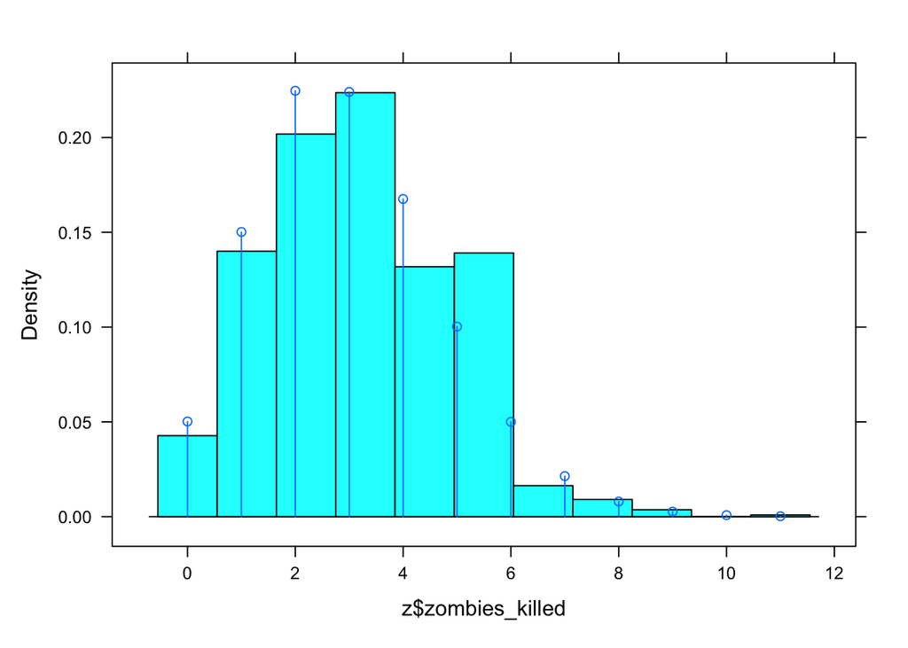

```r
plotDist("pois",lambda=mean(z$zombies_killed),add=TRUE)
```

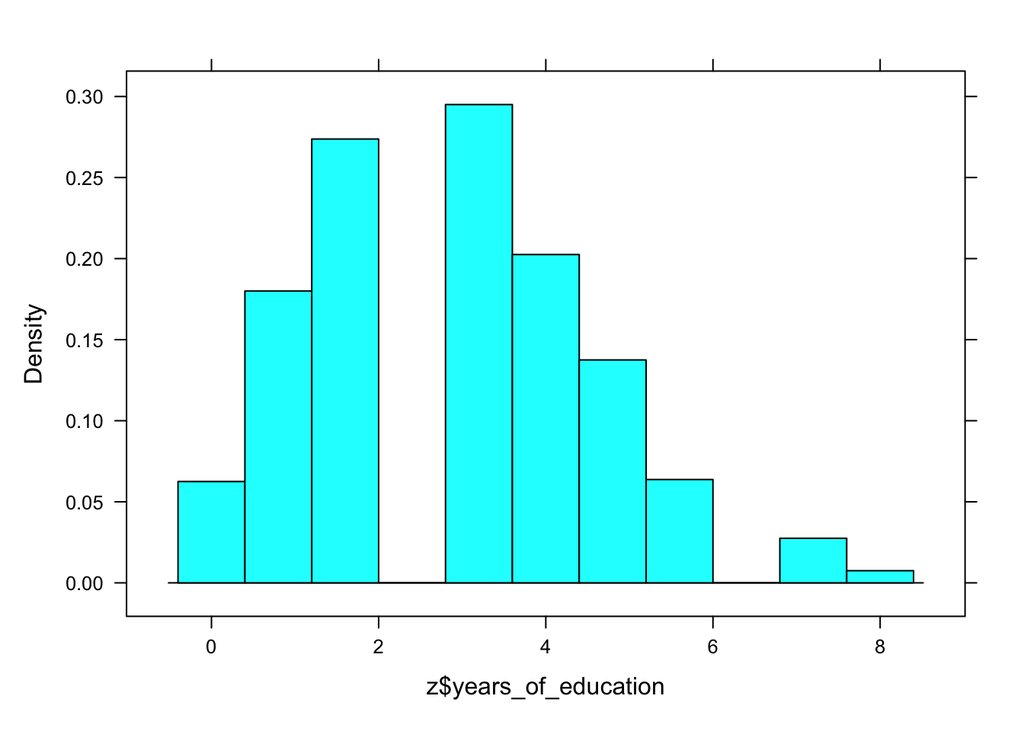

```r
# years of education
histogram(z$years_of_education)
```

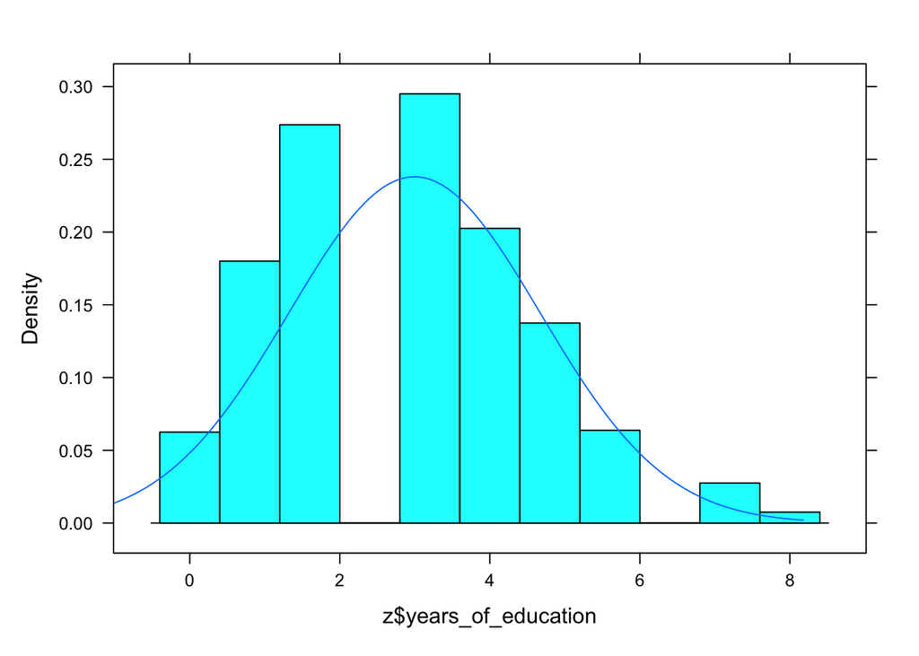

```r
plotDist("norm",mean = mean(z$years_of_education),sd = sd(z$years_of_education),add=TRUE) # years in ed does not seem normally distributed
```

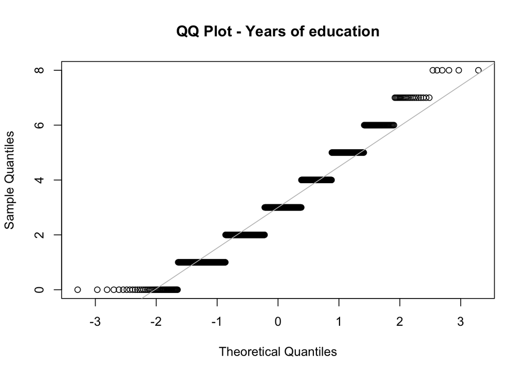

```r
qqnorm(z$years_of_education, main = "QQ Plot - Years of education")
qqline(z$years_of_education, col = "gray") # not looking normal
```

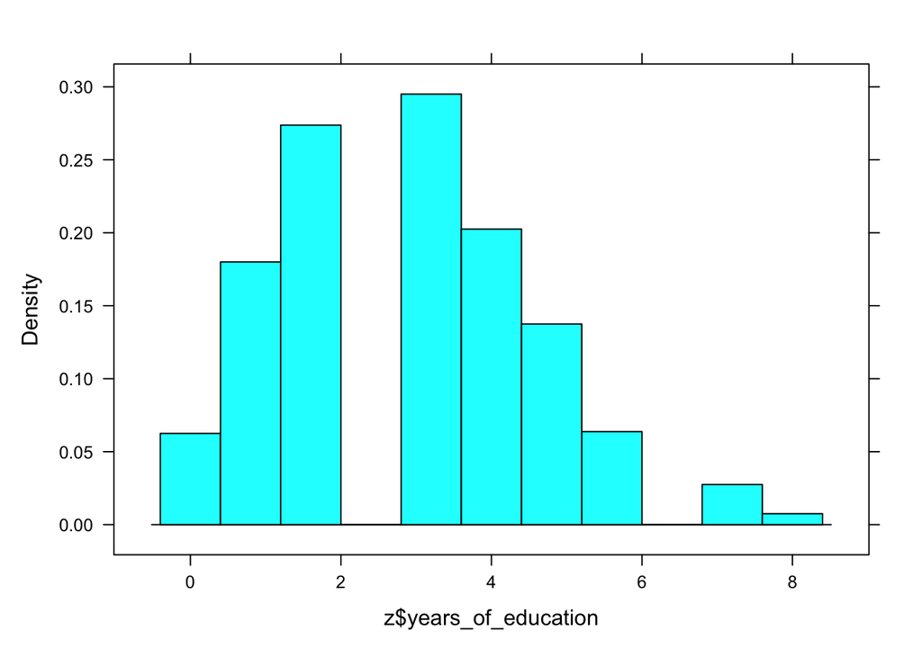

```r
# Let's try it with a poisson distribution
histogram(z$years_of_education)
```

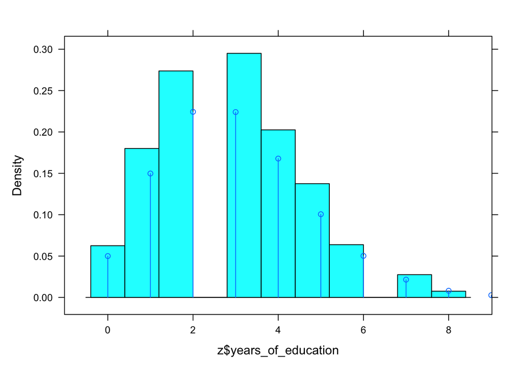

```r
plotDist("pois",lambda=mean(z$years_of_education),add=TRUE)
```

Height and weight seem normally distributed (as expected). Zombies killed and years of education both are discrete variables that do not seem normally distributed. They both look like they could follow a poisson distribution. I tried overlaying a poisson distribution on top of these plots to illustrate that.

Sample subset of zombie survivors (once, 50 individuals, no replacement) and calculate mean and sd for each var. Then estimate the standard error and construct the theoretical 95% confidence interval for each mean. Use standard normal or student’s t distribution to derive critical values needed to calculate lower and upper CI.

```r
# calculate mean and sd of single sample of 50
sample_z <- z %>% sample_n(size=50,replace=FALSE) %>%
  summarize(mean_height = mean(height,na.rm=TRUE),
            sd_height = sd(height,na.rm=TRUE),
            mean_weight = mean(weight,na.rm=TRUE),
            sd_weight = sd(weight,na.rm=TRUE),
            mean_zombies_killed = mean(zombies_killed,na.rm=TRUE),
            sd_zombies_killed = sd(zombies_killed,na.rm=TRUE),
            mean_yearsed = mean(years_of_education,na.rm=TRUE),
            sd_yearsed = sd(years_of_education,na.rm=TRUE))
# calculate standard error
stderror_sample_z <- sample_z %>% summarize(SE_height = sd_height/(sqrt(50)),
                                            SE_weight = sd_weight/(sqrt(50)),
                                            SE_zombies_killed = sd_zombies_killed/(sqrt(50)),
                                            SE_years_ed = sd_yearsed/(sqrt(50)))
# construct 95% confidence interval for each mean
CIs_singlesample <- sample_z %>%
  summarize(CI_height = mean(mean_height) + c(qnorm(0.025),qnorm(0.975)) * sd_height/sqrt(50),
            CI_weight = mean(mean_weight) + c(qnorm(0.025),qnorm(0.975)) * sd_weight/sqrt(50),
            CI_zombies_killed = mean(mean_zombies_killed) + c(qnorm(0.025),qnorm(0.975)) * sd_zombies_killed/sqrt(50),
            CI_years_ed = mean(mean_yearsed) + c(qnorm(0.025),qnorm(0.975)) * sd_yearsed/sqrt(50))

# draw 199 random samples of 50 survivors and calculate mean for each of these samples
library(infer)
reps <- 199
n <- 50
multi_sample_z <- rep_sample_n(z,size=n,reps=reps,replace=FALSE) %>%
  group_by(replicate) %>%
  summarize(mean_height=mean(height,na.rm=TRUE),
            mean_weight = mean(weight,na.rm=TRUE),
            mean_zombies_killed = mean(zombies_killed,na.rm=TRUE),
            mean_yearsed = mean(years_of_education,na.rm=TRUE))
# add the single sampling we did before to the multiple sampling above in a new dataframe so can do stuff
replicate <- 200
mean_single_sample <- bind_cols("replicate"=replicate,select(sample_z,mean_height,mean_weight,mean_zombies_killed,mean_yearsed))
z_sampled200 <- bind_rows(multi_sample_z,mean_single_sample)

# means and standard deviations of the sampling distributions for each variable
(sampling_distr_means_sds <- z_sampled200 %>% summarize(sampdistr_mean_height = mean(mean_height),
                                                       sampdistr_sd_height = sd(mean_height),
                                                       sampdistr_mean_weight = mean(mean_weight),
                                                       sampdistr_sd_weight = sd(mean_weight),
                                                       sampdistr_mean_zombies = mean(mean_zombies_killed),
                                                       sampdistr_sd_zombies = sd(mean_zombies_killed),
                                                       sampdistr_mean_yearsed = mean(mean_yearsed),
                                                       sampdistr_sd_yearsed = sd(mean_yearsed)))
```

```
## # A tibble: 1 × 8
##   sampdistr_mean_height sampdistr_sd_height sampdistr_mean_wei… sampdistr_sd_we…
##                   <dbl>               <dbl>               <dbl>            <dbl>
## 1                  67.7               0.606                144.             2.43
## # … with 4 more variables: sampdistr_mean_zombies <dbl>,
## #   sampdistr_sd_zombies <dbl>, sampdistr_mean_yearsed <dbl>,
## #   sampdistr_sd_yearsed <dbl>
```

```r
# generating confidence interval for each mean directly from the sampling distribution using the central 95% of that distribution - lower bound - 2.5, upper bound - 97.5
CIs_samp_distr <- sampling_distr_means_sds %>%
  summarize(CI_sampdistr_height = sampdistr_mean_height + c(quantile(z_sampled200$mean_height,0.025),quantile(z_sampled200$mean_height,0.975)) * sampdistr_sd_height/sqrt(200),
            CI_sampdistr_weight = sampdistr_mean_weight + c(quantile(z_sampled200$mean_weight,0.025),quantile(z_sampled200$mean_weight,0.975)) * sampdistr_sd_weight/sqrt(200),
            CI_sampdistr_zombies = sampdistr_mean_zombies + c(quantile(z_sampled200$mean_zombies_killed,0.025),quantile(z_sampled200$mean_zombies_killed,0.975)) * sampdistr_sd_zombies/sqrt(200),
            CI_sampdistr_yearsed = sampdistr_mean_yearsed + c(quantile(z_sampled200$mean_yearsed,0.025),quantile(z_sampled200$mean_yearsed,0.975)) * sampdistr_sd_yearsed/sqrt(200))
```

How do the standard deviations of the sampling distribution for each variable compare to the standard errors estimated from your first sample of size 50?

```r
# How do the sds of sampling distribution for each variable compare to the standard errors estimated from first sample of size 50?
# sampling distribution sds
(sampling_distr_means_sds %>% select(sampdistr_sd_height,sampdistr_sd_weight,sampdistr_sd_zombies,sampdistr_sd_yearsed))
```

```
## # A tibble: 1 × 4
##   sampdistr_sd_height sampdistr_sd_weight sampdistr_sd_zombies sampdistr_sd_yea…
##                 <dbl>               <dbl>                <dbl>             <dbl>
## 1               0.606                2.43                0.249             0.224
```

```r
# SE of first sample of 50
stderror_sample_z
```

```
## # A tibble: 1 × 4
##   SE_height SE_weight SE_zombies_killed SE_years_ed
##       <dbl>     <dbl>             <dbl>       <dbl>
## 1     0.669      2.80             0.219       0.205
```

What do sampling distributions for each variable mean look like? Are they normally distributed? What about for those variables that you concluded were not originally drawn from a normal distribution?

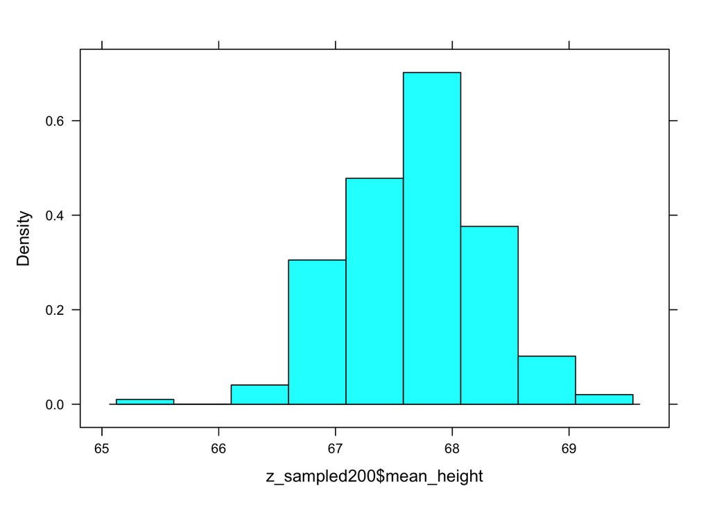

```r
histogram(z_sampled200$mean_height)
```

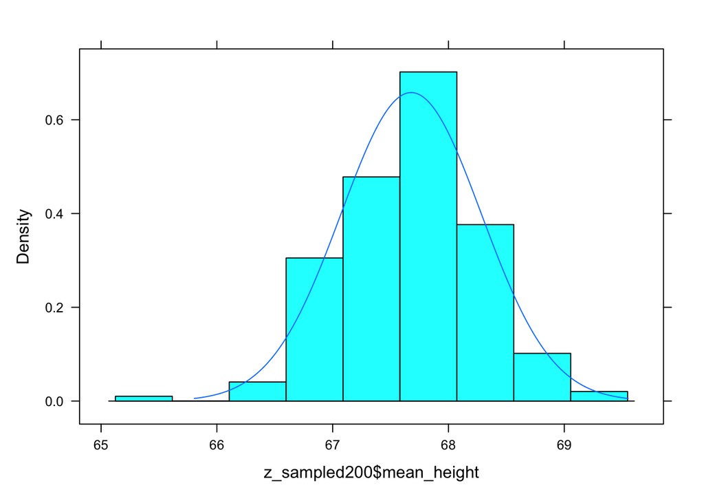

```r
plotDist("norm",mean = mean(z_sampled200$mean_height),sd = sd(z_sampled200$mean_height),add=TRUE)
```

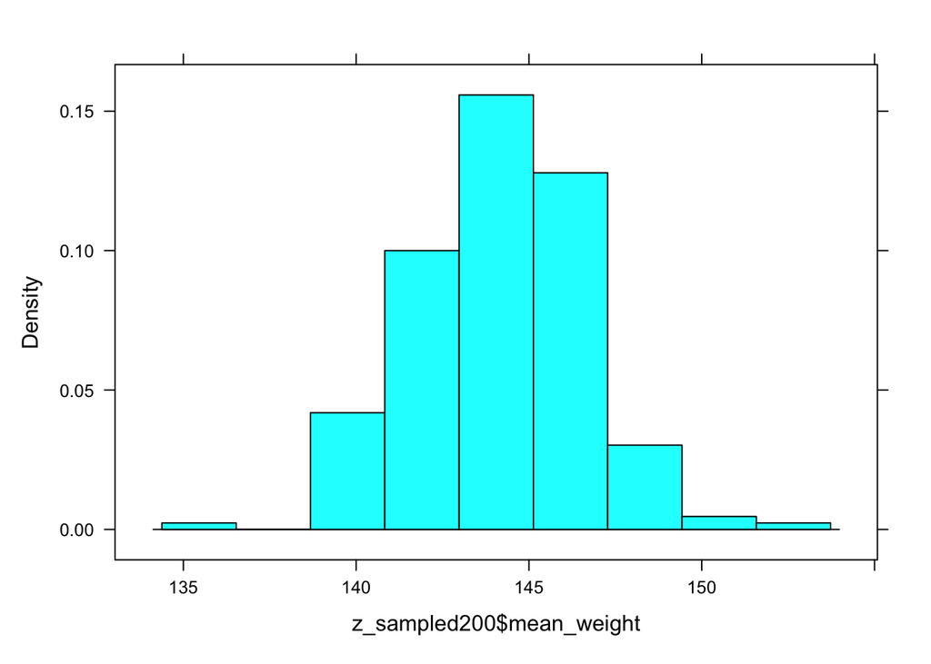

```r
histogram(z_sampled200$mean_weight)
```

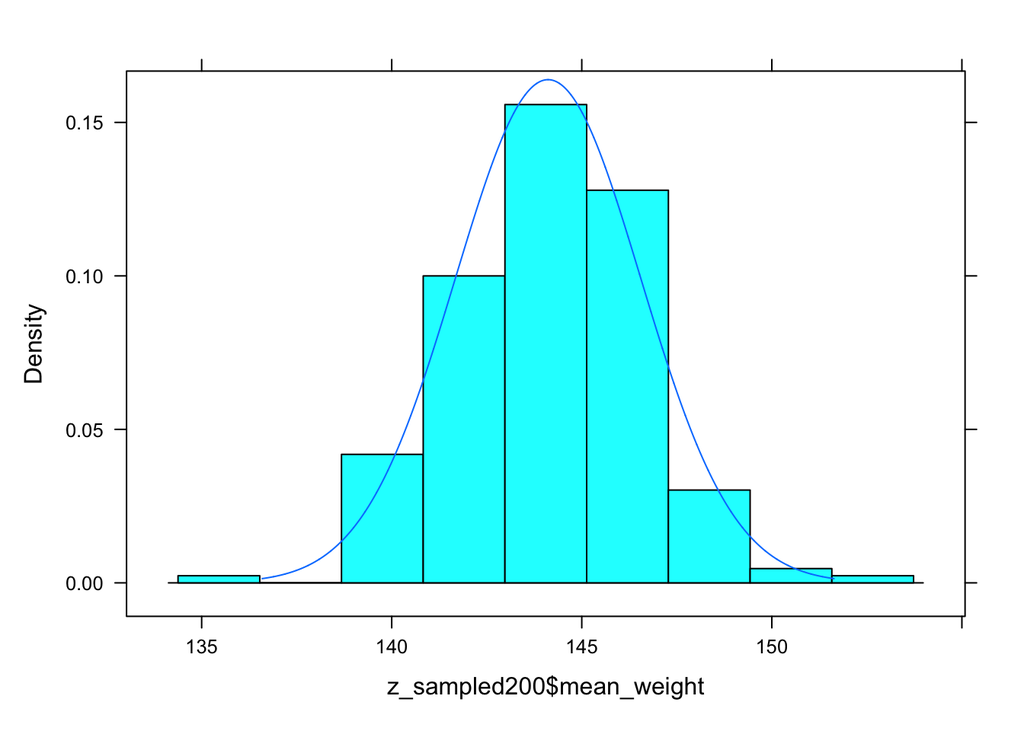

```r
plotDist("norm",mean = mean(z_sampled200$mean_weight),sd = sd(z_sampled200$mean_weight),add=TRUE)
```

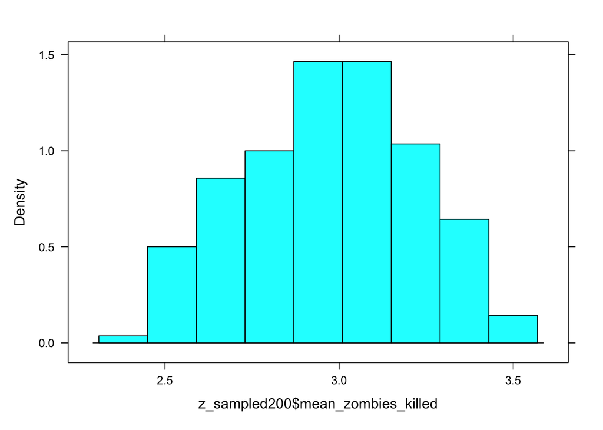

```r
histogram(z_sampled200$mean_zombies_killed)
```

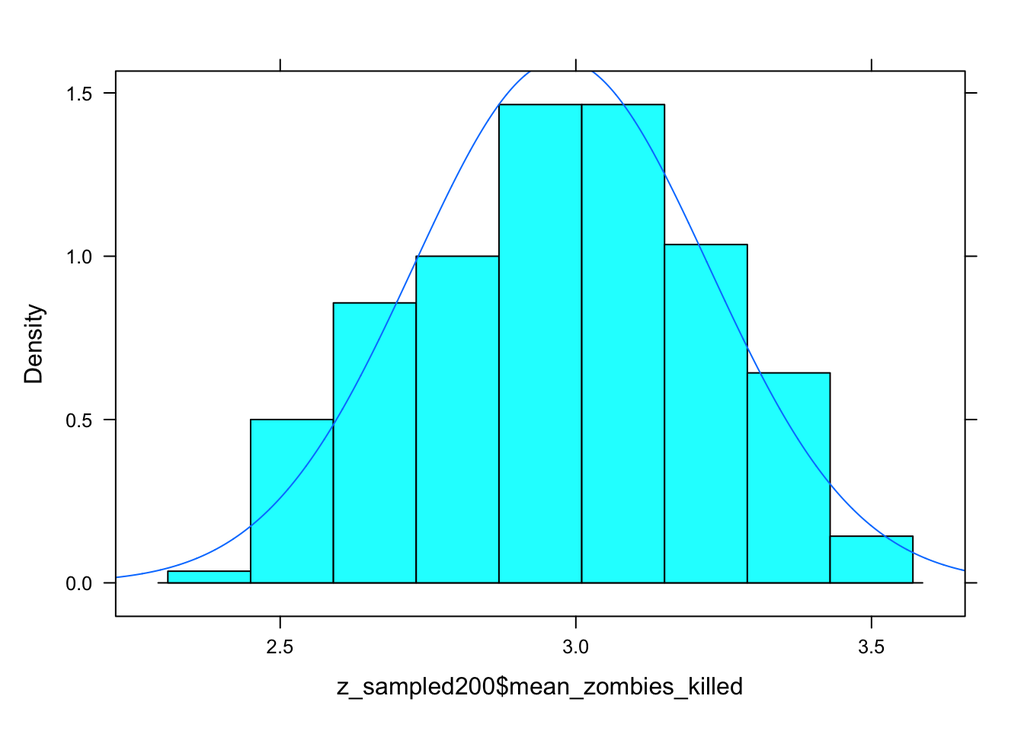

```r
plotDist("norm",mean = mean(z_sampled200$mean_zombies_killed),sd = sd(z_sampled200$mean_zombies_killed),add=TRUE)
```

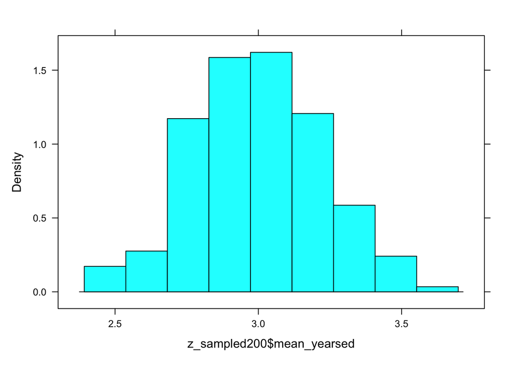

```r
histogram(z_sampled200$mean_yearsed)
```

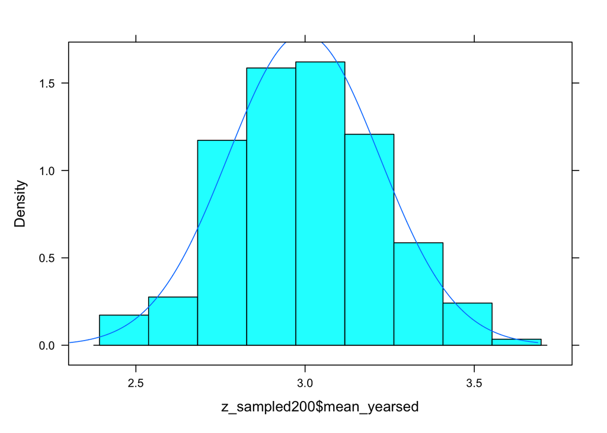

```r
plotDist("norm",mean = mean(z_sampled200$mean_yearsed),sd = sd(z_sampled200$mean_yearsed),add=TRUE)
```

Yes, all the distributions look pretty normal. This makes sense even though some of the underlying data do not have a normal distribution because of the central limit theorem. We are sampling from the data and calculating a statistic (mean) and if we do this with a large enough sample size enough times, we should get a normal curve.

How do the two 95% CIs you estimated compare to one another (i.e., the CI based on one sample and the corresponding sample standard deviation versus the CI based on simulation where you created a sampling distribution across 200 samples)?

```r
# CI based on one sample
CIs_singlesample
```

```
## # A tibble: 2 × 4
##   CI_height CI_weight CI_zombies_killed CI_years_ed
##       <dbl>     <dbl>             <dbl>       <dbl>
## 1      65.4      135.              2.53        2.94
## 2      68.1      146.              3.39        3.74
```

```r
# CI based on sampling distribution across 200 samples
CIs_samp_distr
```

```
## # A tibble: 2 × 4
##   CI_sampdistr_height CI_sampdistr_weight CI_sampdistr_zombies CI_sampdistr_yea…
##                 <dbl>               <dbl>                <dbl>             <dbl>
## 1                70.5                168.                 3.02              3.04
## 2                70.6                170.                 3.04              3.05
```

The 95% confidence intervals are much smaller when calculated from the sampling distribution across 200 samples. This makes sense since we have a lot more samples and can have more confidence in the means that we are calculating from the sampling distribution.